# IE582-Homework4

Hazal Hasret Yurdakul

19 December 2018

**Dataset 3: Online News Popularity**

**Class Imbalanced Data Classification Problem**

```r
str(dataset)
```

```
## Classes 'data.table' and 'data.frame':   39643 obs. of  59 variables:
##  $ n_tokens_title               : num  12 9 9 9 13 10 8 12 11 10 ...
##  $ n_tokens_content             : num  219 255 211 531 1072 ...
##  $ n_unique_tokens              : num  0.664 0.605 0.575 0.504 0.416 ...
##  $ n_non_stop_words             : num  1 1 1 1 1 ...
##  $ n_non_stop_unique_tokens     : num  0.815 0.792 0.664 0.666 0.541 ...
##  $ num_hrefs                    : num  4 3 3 9 19 2 21 20 2 4 ...
##  $ num_self_hrefs               : num  2 1 1 0 19 2 20 20 0 1 ...
##  $ num_imgs                     : num  1 1 1 1 20 0 20 20 0 1 ...
##  $ num_videos                   : num  0 0 0 0 0 0 0 0 0 1 ...
##  $ average_token_length         : num  4.68 4.91 4.39 4.4 4.68 ...
##  $ num_keywords                 : num  5 4 6 7 7 9 10 9 7 5 ...
##  $ data_channel_is_lifestyle    : num  0 0 0 0 0 0 1 0 0 0 ...
##  $ data_channel_is_entertainment: num  1 0 0 1 0 0 0 0 0 0 ...
##  $ data_channel_is_bus          : num  0 1 1 0 0 0 0 0 0 0 ...
```

[output cut: 46 more lines]

```r
dim(dataset)
```

```
## [1] 39643    59
```

We can generate train and test data using dataset and classes. 70% of the data is assigned as train data and the remaining instances are placed in test data.

```r
smp_size <- floor(0.7 * nrow(dataset))

## set the seed to make your partition reproducible
set.seed(123)
train_ind <- sample(seq_len(nrow(dataset)), size = smp_size)

ONP.train <- dataset[train_ind, ]
ONP.test <- dataset[-train_ind, ]

traindata = ONP.train[, 1:58]
testdata = ONP.test[, 1:58]

train.class = ONP.train$class
test.class = ONP.test$class
```

Before starting to generate models, we should generate a balanced dataset.Otherwise, models choose to assign each instance to only one class to achieve better accuracy. However, it would not be true. Therefore, balanced data is generated using ovun.sample function. It basically equate the number of instances for each train and test data.

In the code below, method under instructs the algorithm to perform under sampling. N refers to number of observations in the resulting balanced set.

```r
library(ROSE)
train.class = factor(train.class)
train.data = cbind(data.frame(train.class), traindata)

data_balanced_under <- ovun.sample(train.class ~ ., data = train.data,
    method = "under", N = 7500, seed = 1)$data
str(data_balanced_under)
```

```
## 'data.frame':    7500 obs. of  59 variables:
##  $ train.class                  : Factor w/ 2 levels "0","1": 1 1 1 1 1 1 1 1 1 1 ...
##  $ n_tokens_title               : num  12 10 8 12 12 9 11 13 9 8 ...
##  $ n_tokens_content             : num  713 565 773 186 279 ...
##  $ n_unique_tokens              : num  0.433 0.563 0.524 0.626 0.563 ...
##  $ n_non_stop_words             : num  1 1 1 1 1 ...
##  $ n_non_stop_unique_tokens     : num  0.642 0.745 0.761 0.8 0.692 ...
##  $ num_hrefs                    : num  13 12 14 4 4 0 13 7 8 8 ...
##  $ num_self_hrefs               : num  0 2 0 1 2 0 3 6 5 4 ...
##  $ num_imgs                     : num  1 8 1 1 1 0 3 17 11 1 ...
##  $ num_videos                   : num  1 1 0 0 0 0 0 0 3 0 ...
##  $ average_token_length         : num  4.92 4.5 4.66 4.81 5.07 ...
##  $ num_keywords                 : num  8 7 6 6 7 8 6 10 9 4 ...
##  $ data_channel_is_lifestyle    : num  0 0 0 0 0 0 0 0 0 0 ...
##  $ data_channel_is_entertainment: num  0 0 0 0 0 0 0 1 0 0 ...
```

[output cut: 45 more lines]

```r
table(data_balanced_under$train.class)
```

```
##
##    0    1
## 3891 3609
```

Balanced dataset is created with N=7500 instances.

**1-Penalized Regression**

“penalized” package is used for penalized lasso regression. optL1 function provides the best lambda value between minlambda and maxlambda paramaters. 10-fold cross validation is performed to choose the best lambda value. Also, since the attrition column is binary, “logistic model” is used. Threshold value is chosen as 0.5 and each instance is classified.After choosing lambda value, model is created and trained. Using train data, accuracy is evaluated and compared with test data.Also, 46 regression coefficients out of 59 coefficients are used to generate the penalized lasso model.

```r
traindata = data_balanced_under[, 2:ncol(data_balanced_under)]
train.class = data_balanced_under$train.class
library(penalized)
library(caret)
library(glmnet)
lambda1 <- optL1(train.class, penalized = ~., data = traindata,
    fusedl = FALSE, minlambda1 = 0, maxlambda1 = 2, model = "logistic",
    fold = 10)
```

```
## lambda= 0.763932     12345678910cvl= -4821.073
## lambda= 1.236068     12345678910cvl= -4820.228
## lambda= 1.527864     12345678910cvl= -4819.841
## lambda= 1.708204     12345678910cvl= -4819.627
## lambda= 1.81966  12345678910cvl= -4819.505
## lambda= 1.888544     12345678910cvl= -4819.438
## lambda= 1.931116     12345678910cvl= -4819.392
## lambda= 1.957428     12345678910cvl= -4819.365
## lambda= 1.973689     12345678910cvl= -4819.348
## lambda= 1.983739     12345678910cvl= -4819.338
## lambda= 1.98995  12345678910cvl= -4819.331
## lambda= 1.993789     12345678910cvl= -4819.328
## lambda= 1.996161     12345678910cvl= -4819.326
## lambda= 1.997628     12345678910cvl= -4819.323
## lambda= 1.998534     12345678910cvl= -4819.322
## lambda= 1.999094     12345678910cvl= -4819.321
## lambda= 1.99944  12345678910cvl= -4819.321
## lambda= 1.999654     12345678910cvl= -4819.321
```

```r
pen <- penalized(train.class, penalized = ~., data = traindata,
    lambda1 = lambda1$lambda, model = "logistic", fusedl = FALSE)
```

[output not shown]

[output cut: 4214 more lines]

[output not shown]

```r
pen
```

```
## Penalized logistic regression object
## 59 regression coefficients of which 46 are non-zero
##
## Loglikelihood =   -4766.666
## L1 penalty =  9.957291   at lambda1 =  1.999654
```

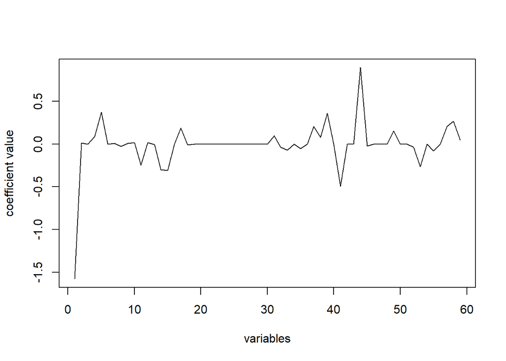

```r
plot(coefficients(pen, "all"), type = "l", xlab = "variables",
    ylab = "coefficient value")
```

```r
ONP.prediction = predict(pen, penalized = traindata)

for (i in 1:length(ONP.prediction)) {
    if (ONP.prediction[i] < 0.5) {
        ONP.prediction[i] = 0
    } else {
        ONP.prediction[i] = 1
    }
}
confusionMatrix(train.class, factor(ONP.prediction))
```

```
## Confusion Matrix and Statistics
##
##           Reference
## Prediction    0    1
##          0 2818 1073
##          1 1585 2024
##
##                Accuracy : 0.6456
##                  95% CI : (0.6347, 0.6564)
##     No Information Rate : 0.5871
##     P-Value [Acc > NIR] : < 2.2e-16
##
##                   Kappa : 0.2865
##  Mcnemar's Test P-Value : < 2.2e-16
##
##             Sensitivity : 0.6400
##             Specificity : 0.6535
##          Pos Pred Value : 0.7242
##          Neg Pred Value : 0.5608
##              Prevalence : 0.5871
##          Detection Rate : 0.3757
##    Detection Prevalence : 0.5188
##       Balanced Accuracy : 0.6468
##
##        'Positive' Class : 0
##
```

```r
prediction.test = predict(pen, penalized = testdata)
for (i in 1:length(prediction.test)) {
    if (prediction.test[i] < 0.5) {
        prediction.test[i] = 0
    } else {
        prediction.test[i] = 1
    }
}

confusionMatrix(factor(test.class), factor(prediction.test))
```

```
## Confusion Matrix and Statistics
##
##           Reference
## Prediction    0    1
##          0 7504 2927
##          1  637  825
##
##                Accuracy : 0.7003
##                  95% CI : (0.692, 0.7086)
##     No Information Rate : 0.6845
##     P-Value [Acc > NIR] : 0.0001013
##
##                   Kappa : 0.1695
##  Mcnemar's Test P-Value : < 2.2e-16
##
##             Sensitivity : 0.9218
##             Specificity : 0.2199
##          Pos Pred Value : 0.7194
##          Neg Pred Value : 0.5643
##              Prevalence : 0.6845
##          Detection Rate : 0.6310
##    Detection Prevalence : 0.8771
##       Balanced Accuracy : 0.5708
##
##        'Positive' Class : 0
##
```

As you can see, accuracy is low about 65%. It is because of we generated the model based on balanced data but our test data is imbalanced one. Therefore, accuracy will be low. Also, accuracy of test data,70%, is higher than accuracy of train data.It may be due to fact that test data has high number of instances compared to train data.

**2-Decision Tree**

```r
library(rpart)
library(rattle)
```

```r
library(rpart.plot)
library(caret)

trials <- expand.grid(minsplit_values = c(10, 15, 20, 25, 50),
    cp_values = c(0.005, 0.001, 0.01))

for (i in 1:nrow(trials)) {
    tree <- rpart(train.class ~ ., data = traindata, method = "class",
        control = rpart.control(cp = trials$cp_values[i], minsplit = trials$minsplit_values[i]))
    cv_error <- tree$cptable[which.min(tree$cptable[, "xerror"]),
        "xerror"]
    conf.mat = confusionMatrix(as.factor(train.class), predict(tree,
        type = "class"))
    print(paste0("cv_error=", cv_error, " accuracy=", unname(conf.mat$overall[1]),
        " cp=", trials$cp_values[i], " minsplit=", trials$minsplit_values[i]))
}
```

```
## [1] "cv_error=0.758104738154614 accuracy=0.6484 cp=0.005 minsplit=10"
## [1] "cv_error=0.766971460238293 accuracy=0.6484 cp=0.005 minsplit=15"
## [1] "cv_error=0.756442227763924 accuracy=0.6484 cp=0.005 minsplit=20"
## [1] "cv_error=0.762261014131338 accuracy=0.6484 cp=0.005 minsplit=25"
## [1] "cv_error=0.761429758935993 accuracy=0.6484 cp=0.005 minsplit=50"
## [1] "cv_error=0.757273482959269 accuracy=0.775333333333333 cp=0.001 minsplit=10"
## [1] "cv_error=0.760321418675533 accuracy=0.775333333333333 cp=0.001 minsplit=15"
## [1] "cv_error=0.767525630368523 accuracy=0.766133333333333 cp=0.001 minsplit=20"
## [1] "cv_error=0.757273482959269 accuracy=0.76 cp=0.001 minsplit=25"
## [1] "cv_error=0.749792186201164 accuracy=0.7276 cp=0.001 minsplit=50"
## [1] "cv_error=0.789138265447492 accuracy=0.6264 cp=0.01 minsplit=10"
## [1] "cv_error=0.790246605707952 accuracy=0.6264 cp=0.01 minsplit=15"
## [1] "cv_error=0.797173732335827 accuracy=0.6264 cp=0.01 minsplit=20"
## [1] "cv_error=0.793294541424217 accuracy=0.6264 cp=0.01 minsplit=25"
## [1] "cv_error=0.788861180382377 accuracy=0.6264 cp=0.01 minsplit=50"
```

```r
tree <- rpart(train.class ~ ., data = traindata, method = "class",
    control = rpart.control(cp = 0.001, minsplit = 25))
tree
```

```
## n= 7500
##
## node), split, n, loss, yval, (yprob)
##       * denotes terminal node
##
##       1) root 7500 3609 0 (0.51880000 0.48120000)
##         2) kw_avg_avg< 3169.697 3951 1431 0 (0.63781321 0.36218679)
##           4) self_reference_avg_sharess< 3459.333 2667  825 0 (0.69066367 0.30933633)
##             8) average_token_length>=4.663093 1417  364 0 (0.74311927 0.25688073)
##              16) kw_avg_max>=143025 1064  227 0 (0.78665414 0.21334586)
##                32) kw_max_avg< 3976.407 662  104 0 (0.84290030 0.15709970) *
##                33) kw_max_avg>=3976.407 402  123 0 (0.69402985 0.30597015)
##                  66) LDA_04< 0.7179604 376  105 0 (0.72074468 0.27925532)
##                   132) num_hrefs< 19.5 321   78 0 (0.75700935 0.24299065) *
##                   133) num_hrefs>=19.5 55   27 0 (0.50909091 0.49090909)
##                     266) min_negative_polarity< -0.8375 13    2 0 (0.84615385 0.15384615) *
##                     267) min_negative_polarity>=-0.8375 42   17 1 (0.40476190 0.59523810)
##                       534) LDA_02>=0.0250006 33   16 0 (0.51515152 0.48484848)
##                        1068) self_reference_avg_sharess< 1867.41 19    5 0 (0.73684211 0.26315789) *
##                        1069) self_reference_avg_sharess>=1867.41 14    3 1 (0.21428571 0.78571429) *
##                       535) LDA_02< 0.0250006 9    0 1 (0.00000000 1.00000000) *
##                  67) LDA_04>=0.7179604 26    8 1 (0.30769231 0.69230769) *
##              17) kw_avg_max< 143025 353  137 0 (0.61189802 0.38810198)
##                34) is_weekend< 0.5 303  105 0 (0.65346535 0.34653465)
##                  68) kw_max_avg< 2861.929 52    8 0 (0.84615385 0.15384615) *
##                  69) kw_max_avg>=2861.929 251   97 0 (0.61354582 0.38645418)
##                   138) global_subjectivity< 0.5186405 206   70 0 (0.66019417 0.33980583)
##                     276) LDA_04< 0.02509911 34    3 0 (0.91176471 0.08823529) *
##                     277) LDA_04>=0.02509911 172   67 0 (0.61046512 0.38953488)
##                       554) kw_min_min< 110.5 81   23 0 (0.71604938 0.28395062) *
##                       555) kw_min_min>=110.5 91   44 0 (0.51648352 0.48351648)
##                        1110) avg_positive_polarity>=0.3418637 53   18 0 (0.66037736 0.33962264)
##                          2220) LDA_04< 0.3406233 31    5 0 (0.83870968 0.16129032) *
##                          2221) LDA_04>=0.3406233 22    9 1 (0.40909091 0.59090909) *
##                        1111) avg_positive_polarity< 0.3418637 38   12 1 (0.31578947 0.68421053) *
##                   139) global_subjectivity>=0.5186405 45   18 1 (0.40000000 0.60000000)
##                     278) self_reference_max_shares>=2150 10    2 0 (0.80000000 0.20000000) *
##                     279) self_reference_max_shares< 2150 35   10 1 (0.28571429 0.71428571) *
##                35) is_weekend>=0.5 50   18 1 (0.36000000 0.64000000)
##                  70) num_self_hrefs>=3.5 13    3 0 (0.76923077 0.23076923) *
```

[output cut: 237 more lines]

```
##                57) kw_avg_avg>=5548.99 49   13 1 (0.26530612 0.73469388) *
##              29) LDA_02>=0.02503613 323   94 1 (0.29102167 0.70897833)
##                58) kw_max_avg>=31250 15    5 0 (0.66666667 0.33333333) *
##                59) kw_max_avg< 31250 308   84 1 (0.27272727 0.72727273)
##                 118) n_unique_tokens>=0.7530712 8    2 0 (0.75000000 0.25000000) *
##                 119) n_unique_tokens< 0.7530712 300   78 1 (0.26000000 0.74000000) *
##            15) self_reference_min_shares>=1450 828  208 1 (0.25120773 0.74879227)
##              30) kw_avg_min>=535.4 110   44 1 (0.40000000 0.60000000)
##                60) kw_min_avg< 2058.389 45   18 0 (0.60000000 0.40000000)
##                 120) global_rate_positive_words>=0.04936074 15    1 0 (0.93333333 0.06666667) *
##                 121) global_rate_positive_words< 0.04936074 30   13 1 (0.43333333 0.56666667)
##                   242) n_unique_tokens< 0.5322388 10    2 0 (0.80000000 0.20000000) *
##                   243) n_unique_tokens>=0.5322388 20    5 1 (0.25000000 0.75000000) *
##                61) kw_min_avg>=2058.389 65   17 1 (0.26153846 0.73846154) *
##              31) kw_avg_min< 535.4 718  164 1 (0.22841226 0.77158774) *
```

```r
printcp(tree)  #display cp table
```

```
##
## Classification tree:
## rpart(formula = train.class ~ ., data = traindata, method = "class",
##     control = rpart.control(cp = 0.001, minsplit = 25))
##
## Variables actually used in tree construction:
##  [1] abs_title_sentiment_polarity average_token_length
##  [3] avg_negative_polarity        avg_positive_polarity
##  [5] global_rate_negative_words   global_rate_positive_words
##  [7] global_sentiment_polarity    global_subjectivity
##  [9] is_weekend                   kw_avg_avg
## [11] kw_avg_max                   kw_avg_min
## [13] kw_max_avg                   kw_max_max
## [15] kw_max_min                   kw_min_avg
## [17] kw_min_max                   kw_min_min
```

[output cut: 38 more lines]

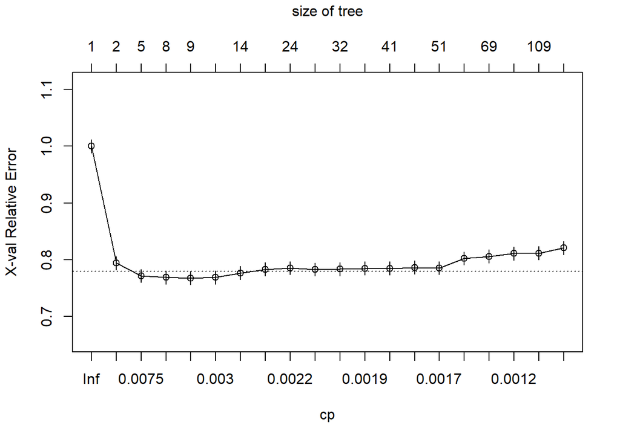

```r
plotcp(tree)
```

```r
confusionMatrix(as.factor(train.class), predict(tree, type = "class"))
```

```
## Confusion Matrix and Statistics
##
##           Reference
## Prediction    0    1
##          0 3011  880
##          1  920 2689
##
##                Accuracy : 0.76
##                  95% CI : (0.7502, 0.7696)
##     No Information Rate : 0.5241
##     P-Value [Acc > NIR] : <2e-16
##
##                   Kappa : 0.5191
##  Mcnemar's Test P-Value : 0.358
##
##             Sensitivity : 0.7660
##             Specificity : 0.7534
##          Pos Pred Value : 0.7738
##          Neg Pred Value : 0.7451
##              Prevalence : 0.5241
##          Detection Rate : 0.4015
##    Detection Prevalence : 0.5188
##       Balanced Accuracy : 0.7597
##
##        'Positive' Class : 0
##
```

```r
## test results
predictions = predict(tree, testdata, type = "class")
confusionMatrix(as.factor(test.class), predictions)
```

```
## Confusion Matrix and Statistics
##
##           Reference
## Prediction    0    1
##          0 6560 3871
##          1  586  876
##
##                Accuracy : 0.6252
##                  95% CI : (0.6165, 0.634)
##     No Information Rate : 0.6009
##     P-Value [Acc > NIR] : 2.667e-08
##
##                   Kappa : 0.116
##  Mcnemar's Test P-Value : < 2.2e-16
##
##             Sensitivity : 0.9180
##             Specificity : 0.1845
##          Pos Pred Value : 0.6289
##          Neg Pred Value : 0.5992
##              Prevalence : 0.6009
##          Detection Rate : 0.5516
##    Detection Prevalence : 0.8771
##       Balanced Accuracy : 0.5513
##
##        'Positive' Class : 0
##
```

Decision tree is constructed using 41 variables.It is because of the cp is very low and we have more than 50 features. As you can see, decision tree achieves 76% of accuracy in train data and 62% of accuracy in test data. Penalized regression model performs better than decision tree in terms of test accuracy.

**3-Support Vector Machine**

We try to set a support vector machine model and tune parameters for this purpose. Gamma and cost parameters are listed with different values.After tuning the parameters, the function chose the best cost and gamma values considering error and performance. Then, model is generated using suggested parameters.

“radial” kernel method is selected and 10-fold cross validation is done.The tuned parameters are found as cost=1 and gamma=0.5. Then, prediction is done for train and test data using those parameters.

Since R session is aborted while evaluating this code chunk, I could not show the results. Therefore, only the codes are available below.

```r
library(e1071)

# tuning

str(traindata)
svm_tune_radial <- tune(svm, train.x = traindata, train.y = factor(train.class),
    kernel = "radial", ranges = list(cost = 10^(0:1), gamma = c(0.1,
        0.5)))
summary(svm_tune_radial)

svm_model_after_tune <- svm(factor(train.class) ~ ., data = traindata,
    kernel = "radial", cost = 1, gamma = 0.5)
summary(svm_model_after_tune)
pred <- predict(svm_model_after_tune, traindata)
confusionMatrix(pred, factor(train.class))

pred <- predict(svm_model_after_tune, testdata[, -5])
confusionMatrix(pred, factor(test.class))
```

**4-Random Forest**

Random forest is performed to predict class information. Firstly, I generated a model with mtry=5 and examine the OOB error and class errors.After that, mtry parameter is tuned using “tuneRF” function. Different mtry levels are considered and the best mtry is selected using OOB(out-of-bag) error. In this case,mtry=5 gives the minimum OOB error and model is generated using this value.

Since R session is aborted while evaluating this code chunk, I could not show the results. Therefore, only the codes are available below.

```r
library(randomForest)
train.class = factor(train.class)
model1 <- randomForest(train.class ~ ., data = traindata, ntree = 500,
    mtry = 5, nodesize = 5)
model1

# Execute the tuning process
set.seed(123)
res <- tuneRF(x = traindata, y = train.class, mtryStart = 5,
    ntreeTry = 500, stepFactor = 5, improve = 0.01)
# Look at results
print(res)
# Find the mtry value that minimizes OOB Error
mtry_opt <- res[, "mtry"][which.min(res[, "OOBError"])]
print(mtry_opt)

model2 <- randomForest(train.class ~ ., data = traindata, ntree = 500,
    mtry = 5, nodesize = 5)
model2

pred <- predict(model2, traindata)
confusionMatrix(pred, train.class)

pred <- predict(model2, testdata)
confusionMatrix(pred, factor(test.class))
```

**5-Gradient Boosting Machine**

Lastly, gradient boosting machine algorithm is used to predict classes. Grid search which iterates over every combination of hyperparameter is performed to assess which combination tends to perform well.Number of trees,learning rates and tree depth paramters are tuned for this purpose. While trying every combination, cross validation and train error are considered to choose the best parameters.

Since R session is aborted while evaluating this code chunk, I could not show the results. Therefore, only the codes are available below.

```r
library(gbm)
library(data.table)
library(caret)
library(dplyr)

# create hyperparameter grid
hyper_grid <- expand.grid(n.trees = c(1000, 5000), shrinkage = c(0.1,
    0.3), interaction.depth = c(1, 5))

optimal_trees = rep(NA, nrow(hyper_grid))  # a place to dump results
min_train_error = rep(NA, nrow(hyper_grid))
min_cv_error = rep(NA, nrow(hyper_grid))  # a place to dump results
# total number of combinations
hyper_grid$n.trees[1]

# grid search
for (i in 1:nrow(hyper_grid)) {
    # train model
    gbm.tune <- gbm(train.class ~ ., distribution = "bernoulli",
        data = traindata, n.trees = hyper_grid$n.trees[i], interaction.depth = hyper_grid$interaction.depth[i],
        shrinkage = hyper_grid$shrinkage[i], cv.folds = 10, n.minobsinnode = 10)

    # add min training error and trees to grid
    optimal_trees[i] <- which.min(gbm.tune$cv.error)
    min_train_error[i] <- sqrt(min(gbm.tune$train.error))
    min_cv_error[i] <- sqrt(min(gbm.tune$cv.error))
}


cbind(hyper_grid, optimal_trees, min_train_error, min_cv_error) %>%
    dplyr::arrange(min_cv_error) %>% head(10)

gbm.fit <- gbm(train.class ~ ., distribution = "bernoulli", data = traindata,
    n.trees = 5000, interaction.depth = 3, shrinkage = 0.1, cv.folds = 10,
    n.minobsinnode = 10)

pred <- predict(gbm.fit, traindata, type = "response")

prediction_res = ifelse(pred < 0.5, 0, 1)

confusionMatrix(factor(prediction_res), factor(train.class))

testdata = testdata[, -5]
pred <- predict(gbm.fit, testdata)
prediction_res = ifelse(pred < 0.5, 0, 1)

confusionMatrix(factor(prediction_res), factor(test.class))
```

**Description**

Attribute Information: 1. class: if number of shares>5000 then 1 else 0 (target) 2. n_tokens_title: Number of words in the title 3. n_tokens_content: Number of words in the content 4. n_unique_tokens: Rate of unique words in the content 5. n_non_stop_words: Rate of non-stop words in the content 6. n_non_stop_unique_tokens: Rate of unique non-stop words in the content 7. num_hrefs: Number of links 8. num_self_hrefs: Number of links to other articles published by Mashable 9. num_imgs: Number of images 10. num_videos: Number of videos 11. average_token_length: Average length of the words in the content 12. num_keywords: Number of keywords in the metadata 13. data_channel_is_lifestyle: Is data channel ‘Lifestyle’? 14. data_channel_is_entertainment: Is data channel ‘Entertainment’? 15. data_channel_is_bus: Is data channel ‘Business’? 16. data_channel_is_socmed: Is data channel ‘Social Media’? 17. data_channel_is_tech: Is data channel ‘Tech’? 18. data_channel_is_world: Is data channel ‘World’? 19. kw_min_min: Worst keyword (min. shares) 20. kw_max_min: Worst keyword (max. shares) 21. kw_avg_min: Worst keyword (avg. shares) 22. kw_min_max: Best keyword (min. shares) 23. kw_max_max: Best keyword (max. shares) 24. kw_avg_max: Best keyword (avg. shares) 25. kw_min_avg: Avg. keyword (min. shares) 26. kw_max_avg: Avg. keyword (max. shares) 27. kw_avg_avg: Avg. keyword (avg. shares) 28. self_reference_min_shares: Min. shares of referenced articles in Mashable 29. self_reference_max_shares: Max. shares of referenced articles in Mashable 30. self_reference_avg_sharess: Avg. shares of referenced articles in Mashable 31. weekday_is_monday: Was the article published on a Monday? 32. weekday_is_tuesday: Was the article published on a Tuesday? 33. weekday_is_wednesday: Was the article published on a Wednesday? 34. weekday_is_thursday: Was the article published on a Thursday? 35. weekday_is_friday: Was the article published on a Friday? 36. weekday_is_saturday: Was the article published on a Saturday? 37. weekday_is_sunday: Was the article published on a Sunday? 38. is_weekend: Was the article published on the weekend? 39. LDA_00: Closeness to LDA topic 0 40. LDA_01: Closeness to LDA topic 1 41. LDA_02: Closeness to LDA topic 2 42. LDA_03: Closeness to LDA topic 3 43. LDA_04: Closeness to LDA topic 4 44. global_subjectivity: Text subjectivity 45. global_sentiment_polarity: Text sentiment polarity 46. global_rate_positive_words: Rate of positive words in the content 47. global_rate_negative_words: Rate of negative words in the content 48. rate_positive_words: Rate of positive words among non-neutral tokens 49. rate_negative_words: Rate of negative words among non-neutral tokens 50. avg_positive_polarity: Avg. polarity of positive words 51. min_positive_polarity: Min. polarity of positive words 52. max_positive_polarity: Max. polarity of positive words 53. avg_negative_polarity: Avg. polarity of negative words 54. min_negative_polarity: Min. polarity of negative words 55. max_negative_polarity: Max. polarity of negative words 56. title_subjectivity: Title subjectivity 57. title_sentiment_polarity: Title polarity 58. abs_title_subjectivity: Absolute subjectivity level 59. abs_title_sentiment_polarity: Absolute polarity level